# Why zztab2fig? A Practical Comparison with pander

Ronald G. Thomas

## Introduction

R provides multiple packages for creating tables from data frames, each with distinct design philosophies. This vignette compares **pander** and **zztab2fig** through practical examples to help you choose the right tool.

**pander** is designed for quick, inline table generation in R Markdown documents. It converts R objects to Markdown format, which Pandoc then renders to HTML, PDF, or Word. This approach is fast and integrates seamlessly with the R Markdown ecosystem. **zztab2fig** takes a different approach: it generates standalone PDF tables via LaTeX compilation, then crops them for inclusion in documents. This produces publication-quality tables with features that Markdown cannot express, such as footnotes, spanning headers, and decimal alignment.

The choice depends on your needs:

- **Quick reports and HTML output**: pander is simpler and faster
- **Journal submissions and formal publications**: zztab2fig provides the control and formatting features required

```r
suppressPackageStartupMessages(library(zztab2fig))
```

# Part 1: Basic Tabling

These examples show that both packages handle simple tables well. The differences emerge in formatting control and output quality.

## Challenge 1: Simple Data Frame

**Task**: Display a basic data frame.

### pander Approach

```r
df <- mtcars[1:5, 1:4]
pander::pander(df)
```

**pander-style output** (rendered via Markdown):

|  | mpg | cyl | disp | hp |
| --- | --- | --- | --- | --- |
| Mazda RX4 | 21.0 | 6 | 160 | 110 |
| Mazda RX4 Wag | 21.0 | 6 | 160 | 110 |
| Datsun 710 | 22.8 | 4 | 108 | 93 |
| Hornet 4 Drive | 21.4 | 6 | 258 | 110 |
| Hornet Sportabout | 18.7 | 8 | 360 | 175 |

### zztab2fig Approach

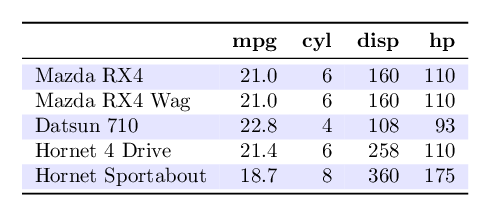

```r
df <- mtcars[1:5, 1:4]
t2f(df, filename = "basic_table", sub_dir = output_dir)
```

**Key difference**: zztab2fig produces a PDF with professional typesetting (booktabs rules, proper spacing). pander produces Markdown for inline display.

## Challenge 2: Column Alignment

**Task**: Left-align text columns, right-align numeric columns.

### pander

```r
df <- data.frame(
  Name = c("Alice", "Bob", "Charlie"),
  Score = c(95.5, 87.2, 91.8),
  Rank = c(1, 3, 2)
)
pander::pander(df, justify = c("left", "right", "right"))
```

**pander-style output:**

| Name | Score | Rank |
| --- | --- | --- |
| Alice | 95.5 | 1 |
| Bob | 87.2 | 3 |
| Charlie | 91.8 | 2 |

### zztab2fig

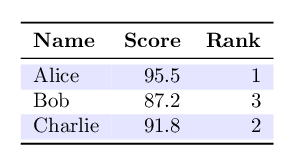

```r
df <- data.frame(
  Name = c("Alice", "Bob", "Charlie"),
  Score = c(95.5, 87.2, 91.8),
  Rank = c(1, 3, 2)
)
t2f(df, filename = "aligned_table", sub_dir = output_dir,
    align = c("l", "r", "r"))
```

**Key difference**: Both handle L/C/R alignment. zztab2fig also supports decimal alignment via siunitx (shown later).

## Challenge 3: Table with Caption

**Task**: Add a descriptive caption.

### pander

```r
df <- iris[1:5, ]
pander::pander(df, caption = "First Five Rows of Iris Dataset")
```

**pander-style output:**

First Five Rows of Iris Dataset

| Sepal.Length | Sepal.Width | Petal.Length | Petal.Width | Species |
| --- | --- | --- | --- | --- |
| 5.1 | 3.5 | 1.4 | 0.2 | setosa |
| 4.9 | 3.0 | 1.4 | 0.2 | setosa |
| 4.7 | 3.2 | 1.3 | 0.2 | setosa |
| 4.6 | 3.1 | 1.5 | 0.2 | setosa |
| 5.0 | 3.6 | 1.4 | 0.2 | setosa |

### zztab2fig

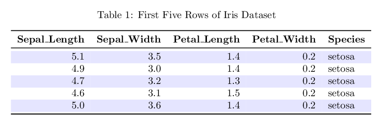

```r
df <- iris[1:5, ]
t2f(df,
    filename = "iris_sample",
    sub_dir = output_dir,
    caption = "First Five Rows of Iris Dataset",
    label = "tab:iris")
```

**Key difference**: zztab2fig adds LaTeX cross-reference labels for use with `\ref{tab:iris}` in documents. pander has no equivalent.

## Challenge 4: Regression Model Output

**Task**: Display coefficients from a linear model.

### pander

```r
model <- lm(mpg ~ cyl + hp + wt, data = mtcars)
pander::pander(model)
```

**pander-style output:**

|  | Estimate | Std. Error | t value | Pr(>\|t\|) |
| --- | --- | --- | --- | --- |
| (Intercept) | 38.7518 | 1.7869 | 21.6870 | 0.0000 |
| cyl | -0.9416 | 0.5509 | -1.7092 | 0.0985 |
| hp | -0.0180 | 0.0119 | -1.5188 | 0.1400 |
| wt | -3.1670 | 0.7406 | -4.2764 | 0.0002 |

### zztab2fig

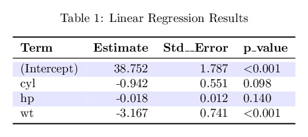

```r
model <- lm(mpg ~ cyl + hp + wt, data = mtcars)
t2f(model,
    filename = "regression",
    sub_dir = output_dir,
    include = c("estimate", "std.error", "p.value"),
    caption = "Linear Regression Results")
```

**Key difference**: Both handle `lm` objects. zztab2fig provides S3 methods for selecting which statistics to display (`include` parameter) and supports additional object types (glm, anova, htest).

# Part 2: Advanced Features

These challenges demonstrate capabilities unique to zztab2fig. pander cannot replicate these without manual LaTeX coding.

## Challenge 5: Table Footnotes

**Task**: Add footnotes explaining abbreviations and significance levels.

### pander

```r
df <- data.frame(
  Variable = c("BMI*", "SBP", "DBP"),
  Mean = c(27.5, 142.3, 88.2),
  SD = c(4.2, 18.5, 11.3)
)
pander::pander(df, caption = "Clinical Measurements")
# Footnotes must be added as separate text below the table
```

**pander-style output** (no footnote support):

Clinical Measurements

| Variable | Mean | SD |
| --- | --- | --- |
| BMI* | 27.5 | 4.2 |
| SBP | 142.3 | 18.5 |
| DBP | 88.2 | 11.3 |

*Note: With pander, footnotes must be added as separate text below the table.*

### zztab2fig

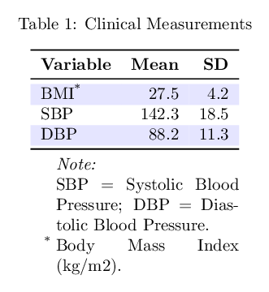

```r
df <- data.frame(
  Variable = c("BMI", "SBP", "DBP"),
  Mean = c(27.5, 142.3, 88.2),
  SD = c(4.2, 18.5, 11.3)
)

df$Variable[1] <- t2f_mark("BMI", 1, "symbol")

fn <- t2f_footnote(
  general = "SBP = Systolic Blood Pressure; DBP = Diastolic Blood Pressure.",
  symbol = "Body Mass Index (kg/m2).",
  threeparttable = TRUE
)

t2f(df,
    filename = "clinical_footnotes",
    sub_dir = output_dir,
    caption = "Clinical Measurements",
    footnote = fn)
```

**Advantage**: zztab2fig produces proper LaTeX footnotes using threeparttable, with support for general notes, numbered notes, and symbol notes.

## Challenge 6: Spanning Column Headers

**Task**: Group related columns under a common header (e.g., “Treatment” and “Control” groups).

### pander

```r
# pander cannot create spanning headers
# Best approximation: rename columns to indicate grouping
names(df) <- c("Outcome", "Treatment Mean", "Treatment SD",
               "Control Mean", "Control SD")
pander::pander(df)
```

**pander-style output** (workaround with renamed columns):

| Outcome | Treatment Mean | Treatment SD | Control Mean | Control SD |
| --- | --- | --- | --- | --- |
| Score A | 45.2 | 8.3 | 42.1 | 7.9 |
| Score B | 38.7 | 6.2 | 37.9 | 5.8 |

**Limitation**: pander cannot create multi-column headers. Column names must encode the grouping, resulting in longer, less readable headers.

### zztab2fig

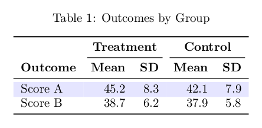

```r
df <- data.frame(
  Outcome = c("Score A", "Score B"),
  T_Mean = c(45.2, 38.7),
  T_SD = c(8.3, 6.2),
  C_Mean = c(42.1, 37.9),
  C_SD = c(7.9, 5.8)
)
names(df) <- c("Outcome", "Mean", "SD", "Mean", "SD")

hdr <- t2f_header_above(
  " " = 1,
  "Treatment" = 2,
  "Control" = 2
)

t2f(df,
    filename = "spanning_header",
    sub_dir = output_dir,
    caption = "Outcomes by Group",
    header_above = hdr)
```

**Advantage**: zztab2fig creates proper LaTeX multicolumn headers with cmidrule separators, essential for clinical trial and research tables.

## Challenge 7: Multi-Row Cells (Hierarchical Data)

**Task**: Merge repeated values vertically to show data hierarchy.

### pander

```r
df <- data.frame(
  Category = c("Treatment", "Treatment", "Control", "Control"),
  Subgroup = c("Male", "Female", "Male", "Female"),
  N = c(45, 52, 48, 49),
  Response = c("72%", "68%", "45%", "42%")
)
# pander displays repeated values without merging
pander::pander(df)
```

**pander-style output** (no cell merging):

| Category | Subgroup | N | Response |
| --- | --- | --- | --- |
| Treatment | Male | 45 | 72% |
| Treatment | Female | 52 | 68% |
| Control | Male | 48 | 45% |
| Control | Female | 49 | 42% |

**Limitation**: pander cannot merge cells vertically. Repeated values clutter the table and obscure the hierarchical structure.

### zztab2fig

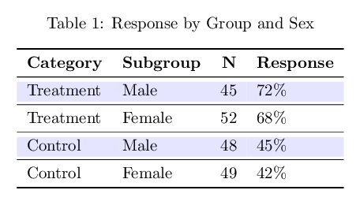

```r
df <- data.frame(
  Category = c("Treatment", "Treatment", "Control", "Control"),
  Subgroup = c("Male", "Female", "Male", "Female"),
  N = c(45, 52, 48, 49),
  Response = c("72%", "68%", "45%", "42%")
)

t2f(df,
    filename = "multirow",
    sub_dir = output_dir,
    caption = "Response by Group and Sex",
    collapse_rows = t2f_collapse_rows(
      columns = 1,
      valign = "middle",
      latex_hline = "major"
    ))
```

## Challenge 8: Decimal Point Alignment

**Task**: Align numbers on the decimal point for easy visual comparison.

### pander

```r
df <- data.frame(
  Item = c("A", "B", "C"),
  Value1 = c(1.5, 123.45, 12.345),
  Value2 = c(0.001, 10.1, 1000.01)
)
# pander uses right-alignment (no decimal alignment)
pander::pander(df, justify = c("left", "right", "right"))
```

**pander-style output** (right-aligned, not decimal-aligned):

| Item | Value1 | Value2 |
| --- | --- | --- |
| A | 1.500 | 0.001 |
| B | 123.450 | 10.100 |
| C | 12.345 | 1000.010 |

**Limitation**: pander only supports left/center/right alignment, not decimal alignment. Values with different decimal places are harder to compare visually.

### zztab2fig

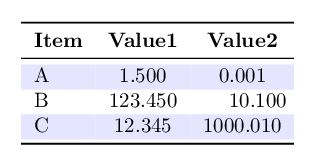

```r
df <- data.frame(
  Item = c("A", "B", "C"),
  Value1 = c(1.5, 123.45, 12.345),
  Value2 = c(0.001, 10.1, 1000.01)
)

t2f(df,
    filename = "decimal_aligned",
    sub_dir = output_dir,
    align = list(
      "l",
      t2f_siunitx(table_format = "3.3"),
      t2f_siunitx(table_format = "4.2")
    ))
```

## Challenge 9: Journal-Specific Themes

**Task**: Format a table for NEJM (New England Journal of Medicine) submission.

### pander

```r
# pander has no journal-specific themes
# Manual formatting required for each style guide
pander::panderOptions("table.style", "rmarkdown")
pander::pander(df, caption = "Baseline Characteristics")
```

**pander-style output** (default styling, no NEJM formatting):

Baseline Characteristics

| Characteristic | Treatment | Placebo |
| --- | --- | --- |
| Age, years | 65.2 (8.4) | 64.8 (8.1) |
| Male sex, n (%) | 142 (58%) | 138 (56%) |
| BMI, kg/m2 | 27.3 (4.1) | 27.1 (3.9) |

**Limitation**: pander provides no built-in journal themes. Meeting specific journal requirements requires manual formatting.

### zztab2fig

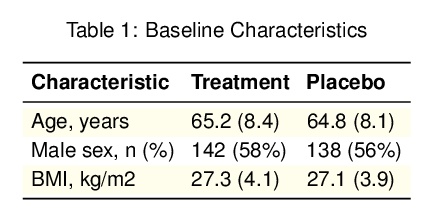

```r
df <- data.frame(
  Characteristic = c("Age, years", "Male sex, n (%)", "BMI, kg/m2"),
  Treatment = c("65.2 (8.4)", "142 (58%)", "27.3 (4.1)"),
  Placebo = c("64.8 (8.1)", "138 (56%)", "27.1 (3.9)")
)

t2f(df,
    filename = "nejm_table",
    sub_dir = output_dir,
    caption = "Baseline Characteristics",
    theme = "nejm")
```

**Advantage**: zztab2fig includes built-in themes for NEJM, APA, Nature, and a minimal style. Each theme sets appropriate fonts, spacing, and rules.

## Challenge 10: Model Comparison Table

**Task**: Display multiple regression models side-by-side with significance stars.

### pander

```r
m1 <- lm(mpg ~ cyl, data = mtcars)
m2 <- lm(mpg ~ cyl + hp, data = mtcars)
m3 <- lm(mpg ~ cyl + hp + wt, data = mtcars)

# pander displays one model at a time
pander::pander(m1)
pander::pander(m2)
pander::pander(m3)
# Side-by-side comparison requires manual table construction
```

**pander-style output** (separate tables, no side-by-side comparison):

Model 1:

|  | Estimate | Std. Error | t value | Pr(>\|t\|) |
| --- | --- | --- | --- | --- |
| (Intercept) | 37.8846 | 2.0738 | 18.2678 | 0 |
| cyl | -2.8758 | 0.3224 | -8.9197 | 0 |

Model 2:

|  | Estimate | Std. Error | t value | Pr(>\|t\|) |
| --- | --- | --- | --- | --- |
| (Intercept) | 36.9083 | 2.1908 | 16.8470 | 0.0000 |
| cyl | -2.2647 | 0.5759 | -3.9325 | 0.0005 |
| hp | -0.0191 | 0.0150 | -1.2747 | 0.2125 |

Model 3:

|  | Estimate | Std. Error | t value | Pr(>\|t\|) |
| --- | --- | --- | --- | --- |
| (Intercept) | 38.7518 | 1.7869 | 21.6870 | 0.0000 |
| cyl | -0.9416 | 0.5509 | -1.7092 | 0.0985 |
| hp | -0.0180 | 0.0119 | -1.5188 | 0.1400 |
| wt | -3.1670 | 0.7406 | -4.2764 | 0.0002 |

**Limitation**: pander cannot create comparative model tables automatically. Each model must be displayed separately, making comparison difficult.

### zztab2fig

```r
m1 <- lm(mpg ~ cyl, data = mtcars)
m2 <- lm(mpg ~ cyl + hp, data = mtcars)
m3 <- lm(mpg ~ cyl + hp + wt, data = mtcars)

t2f_regression(
  Model1 = m1,
  Model2 = m2,
  Model3 = m3,
  stars = TRUE,
  filename = "model_comparison",
  sub_dir = output_dir
)
```

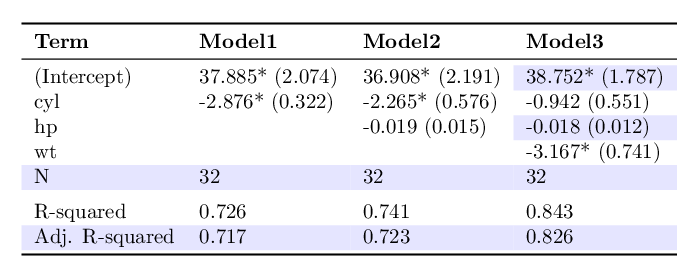

**Advantage**: `t2f_regression()` automatically aligns terms across models, adds significance stars, and includes model statistics (N, R-squared).

## Challenge 11: Complex Combined Features

**Task**: Create a publication-quality table with footnotes, spanning headers, multi-row cells, and NEJM styling.

### pander

```r
# This combination cannot be achieved in pander
# Requires manual LaTeX coding
```

### zztab2fig

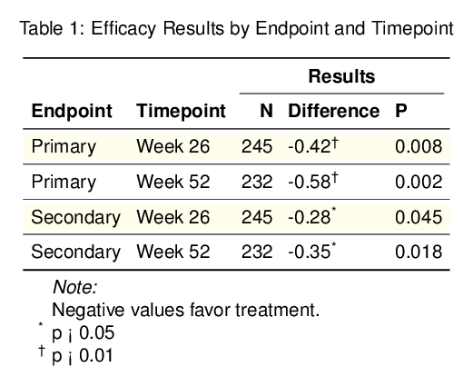

```r
df <- data.frame(
  Endpoint = c("Primary", "Primary", "Secondary", "Secondary"),
  Timepoint = c("Week 26", "Week 52", "Week 26", "Week 52"),
  N = c(245, 232, 245, 232),
  Difference = c(-0.42, -0.58, -0.28, -0.35),
  P = c("0.008", "0.002", "0.045", "0.018")
)

df$Difference <- sapply(seq_len(nrow(df)), function(i) {
  p <- as.numeric(df$P[i])
  if (p < 0.01) t2f_mark(as.character(df$Difference[i]), 2, "symbol")
  else if (p < 0.05) t2f_mark(as.character(df$Difference[i]), 1, "symbol")
  else as.character(df$Difference[i])
})

hdr <- t2f_header_above(" " = 2, "Results" = 3)

fn <- t2f_footnote(
  general = "Negative values favor treatment.",
  symbol = c("p < 0.05", "p < 0.01")
)

t2f(df,
    filename = "complex_table",
    sub_dir = output_dir,
    caption = "Efficacy Results by Endpoint and Timepoint",
    caption_short = "Efficacy Results",
    header_above = hdr,
    collapse_rows = t2f_collapse_rows(1, valign = "top"),
    footnote = fn,
    theme = "nejm")
```

# Part 3: R Markdown Workflow

## Challenge 12: Inline Tables Without Floats

**Task**: Insert a coefficient table exactly where the code chunk appears, with proper caption and cross-reference but without LaTeX float positioning.

### pander

```r
model <- lm(mpg ~ cyl + hp, data = mtcars)
pander::pander(model)
```

pander tables appear inline, but captions use Markdown syntax that may not produce proper table numbering or cross-references in PDF output.

### zztab2fig

The `t2f_inline()` function is designed for exactly this use case:

```r
model <- lm(mpg ~ cyl + hp, data = mtcars)
t2f_inline(model,
           width = "3in",
           align = "left",
           caption = "Linear model coefficients",
           label = "tab:model",
           caption_position = "above")
```

**Key features**:

- Table appears exactly at code chunk location (no float)
- Uses `\captionof{table}{...}` for proper “Table 1:” numbering
- Cross-references work with `\ref{tab:model}`
- `caption_position`: “above” (default, standard for tables) or “below”
- Auto-detects PDF vs HTML output format

**Convenience function for models**:

```r
t2f_coef(model, caption = "Model results", label = "tab:coef")
```

This is equivalent to `t2f_inline()` with sensible defaults for coefficient tables (width = “3in”, align = “left”).

**Note**: When using captions with `t2f_inline()`, add to your R Markdown YAML:

```yaml
header-includes:
  - \usepackage{caption}
```

# Summary

## Feature Comparison

| Feature | pander | zztab2fig |
| --- | --- | --- |
| Basic data frames | Yes | Yes |
| Column alignment (L/C/R) | Yes | Yes |
| Decimal alignment | No | Yes (siunitx) |
| Captions | Yes | Yes + short captions |
| Cross-reference labels | No | Yes |
| Non-float captions | No | Yes (captionof) |
| Caption position control | No | Yes (above/below) |
| Table footnotes | No | Yes (4 notation types) |
| Spanning headers | No | Yes |
| Multi-row cells | No | Yes |
| Multi-page tables | No | Yes (longtable) |
| Journal themes | No | Yes (NEJM, APA, Nature) |
| Model comparison | No | Yes |
| Statistical object S3 methods | Partial | Yes (20+ types via broom) |
| Output formats | Markdown | PDF, PNG, SVG, TEX |
| Inline R Markdown workflow | Yes | Yes (t2f_inline) |

## When to Use Each Package

### Choose pander when:

- Creating R Markdown documents for HTML or Word output
- Need quick, inline display of many R object types
- Document will be processed through Pandoc
- Simple tables with basic formatting are sufficient
- Rapid iteration is more important than typographic quality

### Choose zztab2fig when:

- Creating tables for journal submission
- Need footnotes, spanning headers, or multi-row cells
- Working with LaTeX documents directly
- Require decimal alignment for numeric comparison
- Want consistent journal-specific styling (NEJM, APA, Nature)
- Need cropped PDF tables for inclusion in external documents
- Building model comparison tables
- Want proper table numbering without float positioning

## v0.2.0 Features Used in This Vignette

This vignette demonstrates several features introduced in zztab2fig v0.2.0: - **t2f_inline()**: Inline tables for R Markdown without floats - **t2f_coef()**: Quick coefficient tables with sensible defaults - **caption_position**: Control caption placement (above/below) - **S3 methods**: Support for 20+ object types via broom integration - **Theme system**: Built-in NEJM theme (`theme = "nejm"`) - **t2f_regression()**: Side-by-side model comparison - **t2f_footnote()**: Structured footnotes with multiple notation types - **t2f_header_above()**: Spanning column headers - **t2f_collapse_rows()**: Multi-row cell merging - **t2f_siunitx()**: Decimal alignment - **t2f_mark()**: Footnote markers in cells - **caption_short**: Short captions for List of Tables

For complete documentation of these features, see the “Advanced Features” and “Object Types and Themes” vignettes.